# BIOS 611 HW3 Exploratory Analysis, tibbles, and data import (Chapters 7, 10, and 11.2)

# Exercise 5

1. Instead of summarising the conditional distribution with a boxplot, you could use a frequency polygon. What do you need to consider when using `cut_width()` vs `cut_number()`? How does that impact a visualisation of the 2d distribution of `carat` and `price`?

   Answer: `cut_width` divides the variable into bins of the width specified. With `cut_number` you specifiy the amount of bins you want and it divides the data into an approximately equal amount of points into each of the bins. So you need to consider the binwidth with `cut_width` and the number of bins with `cut_number`. You usually dont need as many bins for a frequency polygon as you need for a boxplot. The frequency polygon is overlaid so it makes it easy to compare the distributions of each of the subsets of the data.

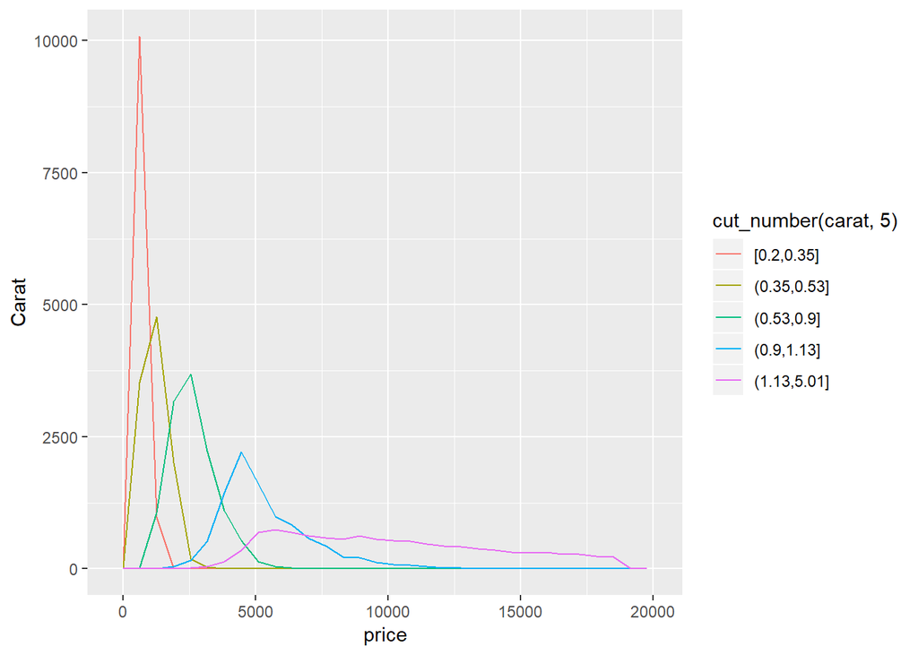

   ```r
   diamonds%>% ggplot(aes(x=price))+geom_freqpoly(aes(color=cut_number(carat,5)))+ylab("Carat")
   ```

2. Visualise the distribution of carat, partitioned by price. (Hint: consider a boxplot)

   Answer:

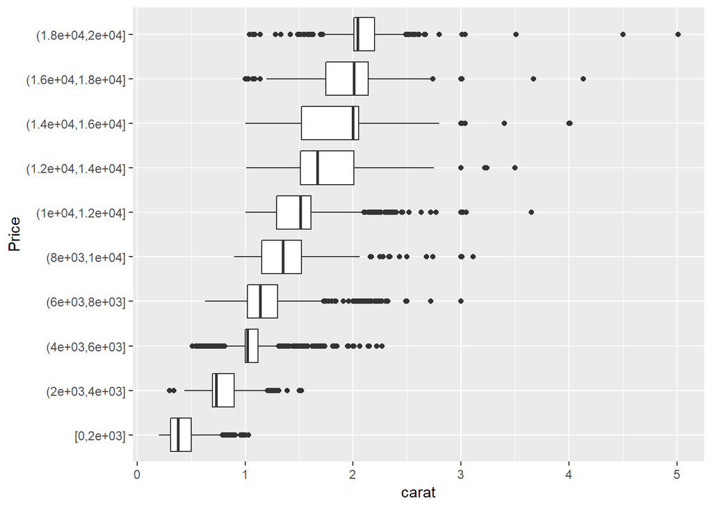

   ```r
   diamonds%>% ggplot(aes(y=carat))+geom_boxplot(aes(x=cut_width(price,2000,boundary=0)))+coord_flip()+xlab("Price")
   ```

3. How does the price distribution of very large diamonds compare to small diamonds? Is it as you expect, or does it surprise you? (Hint: Assuming you want to do a linear regression, is there any violation?)

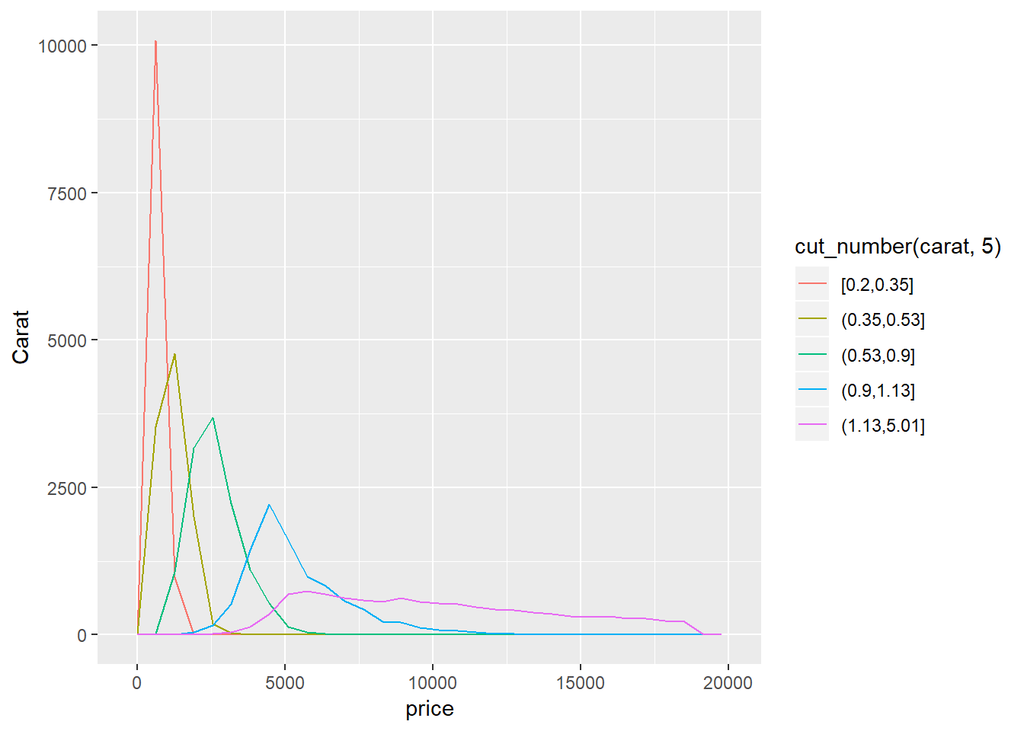

   ```r
   diamonds%>% ggplot(aes(x=price))+geom_freqpoly(aes(color=cut_number(carat,5)))+ylab("Carat")
   ```